# Tree phenology analysis with R

Ricarda Scholte-Reh

2024-10-12

# 1 Introduction

Content of this module  
- Overview of methods to study the impact of climate, and it’s change, on tree phenology  
- Basics about tree phenology (esp. dormancy)  
- How to use the chillR package for R - Impact that climate change has to projection models  
- Appreciation for the importance of risks and uncertainty in climate change projection  
- Understanding of how to use some staple tools of R code development  
- Ability to use chillR functions for climate change impact projection  
- Ability to use chillR functions for tree phenology analysis  
- Understanding and ability to use the PhenoFlex dormancy analysis framework

Requirements for rewarding credits  
- NO exam  
- Participation in the course will be graded  
- Submit a “learning logbook” at the end of the semester made with Rmarkdown  
- You will record all learning and coding work  
- The logbook will be also controlled during the semester

# 2 The tools we use

- R and RStudio
- git and github
- Rmarkdown

Useful links for coding:  
- [different themes for Rmarkdown](https://bootswatch.com/3/)  
- [Chapter3 for basics](https://bookdown.org/yihui/rmarkdown/html-document.html)  
- [cheat sheet](https://rmarkdown.rstudio.com/lesson-15.HTML)  
- [basic code blocks](https://rmarkdown.rstudio.com/authoring_basics.html)

# 3 Tree dormancy

## 3.1 Exercises

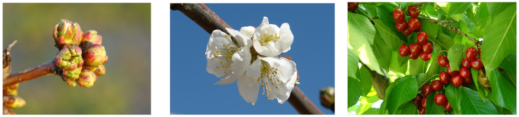

Picture 01: Phenological stages of a cherry tree

# 4 Climate change and impact projection

## 4.1 Exercises

1. List the main drivers of climate change at the decade to century scale, and briefly explain the mechanism through which the currently most important driver affects our climate.
- Sun
  - Warms Earth through solar radiation
  - Activity varies slightly (cyclically) over time, as evidenced by sunspots
  - Differences in energy that reaches Earth are small
  - Explains only a small fraction of current climate variability
  - Important driver of climate change on geological timescales, but not of recent climate change
- Aerosols
  - Suspensions of liquid, solid, or mixed particles with highly variable chemical composition and size distribution
  - Natural sources: Sea salt, dust, volcanic eruptions, fires
  - Anthropogenic sources: combustion processes (e.g. power plants, cars, fires and cook stoves)
  - Generally have a cooling effect on the climate, especially locally
  - Human aerosol emissions are a major climate driver in some places
  - Global aerosol distribution – fraction of Aerosol Optical Depth related to human emissions
  - Major climate driver in industrial centers
- Clouds
  - Can have both cooling and warming effects
  - Net effect likely important but poorly understood
  - Positive feedback with warming possible: warmer -> more clouds -> warmer -> more evaporation -> more clouds
- Ozone
  - Surface (tropospheric) ozone: constituent of smog, health hazard (bad ozone)
  - Stratospheric ozone (10-35 km above surface): shields Earth from UV-B radiation (good ozone)
  - Greenhouse gas: presence in the stratosphere has a warming effect
  - Destroyed by chlorofluorocarbons (CFCs)
- Surface albedo
  - Reflection of radiation by the land surface
  - Light surfaces (e.g. ice, snow) reflect almost all radiation, dark surfaces (ocean, dark soil, forest) very little
  - Land cover change can affect albedo
- Greenhouse gases
  - Atmospheric gases that trap heat on Earth
  - Can absorb only radiation of certain wavelengths
  - Short-wave radiation from the sun passes
  - Long-wave radiation from Earth surface is absorbed
  - Greenhouse effects warms the planet
- Long-term drivers
  - Trends in solar activity
    - Star life cycle, gradually decreasing luminosity over billions of years
  - Ocean currents/continent constellations
    - Global heat transfer (Gulf Stream, Antarctic Circumpolar Current; millions of years)
  - Plants vs. animals (hypothetical)
    - Balance of CO2 production and consumption
    - Back and forth between ‘Snowball Earth’ and ‘Greenhouse Earth’
  - Volcanic and meteorite activity
    - Volcanoes emit CO2 (warming) and dust (cooling) ; supervolcanoes caused massive effects
    - Meteorite impacts can raise dust concentrations for years
  - Trends in solar activity
    - Star life cycle, gradually decreasing luminosity over billions of years
  - Ocean currents/continent constellations
    - Global heat transfer (Gulf Stream, Antarctic Circumpolar Current; millions of years)
  - Plants vs. animals (hypothetical)
    - Balance of CO2 production and consumption
    - Back and forth between ‘Snowball Earth’ and ‘Greenhouse Earth’
  - Volcanic and meteorite activity
    - Volcanoes emit CO2 (warming) and dust (cooling) ; supervolcanoes caused massive effects
    - Meteorite impacts can raise dust concentrations for years
  - Milankovic cycles
    - Variation in Earth’s orbit: eccentricity, axial tilt and precession (19,000 to 400,000-year cycles)
    - Most likely cause of Ice Ages
2. Explain briefly what is special about temperature dynamics of recent decades, and why we have good reasons to be concerned.
- Recently the mean temperatures are globally rising clearly and very drastically
- Especially in the last 50 to 100 years
- this an other facors have a great influence in our climate and weather (regional and global)
- we will and already do experience more extreme weather (like more dry periods, extreme rain, mild and extreme winter)
- most important is the rapid warming (as conclusion)
3. What does the abbreviation ‘RCP’ stand for, how are RCPs defined, and what is their role in projecting future climates?
- RCP -> Representative Concentration Pathways
- RCPs project future greenhouse gas concentrations (NOT emissions) based on different climate change scenarios until the year 2100
- the different scenarios are labeled after the possible radiative forcing values in the year 2100
4. Briefly describe the 4 climate impact projection methods described in the fourth video.
- statistical models
- species distribution modeling
- process-based models
- climate analouge analysis

# 5 Winter chill projections

## 5.1 Exercises

1. Sketch out three data access and processing challenges that had to be overcome in order to produce chill projections with state-of-the-art methodology.
   - three ways to view data
   - difficulties with processing
   - Chilling Hours Model
     - not a good model
     - especially for warm climates not trustable
2. Outline, in your understanding, the basic steps that are necessary to make such projections.
   - Steps needed for todays projections

# 6 Manual chill analysis

## 6.1 Computing Chilling Hours from temperature data

## 6.2 Our first chill function

## 6.3 Exercises

```r
library(chillR)
library(knitr)
library(pander)
library(kableExtra)
```

```r
warm_hours <- function(THourly,
                        startYear,
                        startMonth,
                        startDay,
                        startHour,
                        endYear,
                        endMonth,
                        endDay,
                        endHour)

{THourly[,"Warm_Hour"] <- THourly$Temp > 25
  Start_row <- which(hourtemps$Year == startYear &
                     hourtemps$Month == startMonth &
                     hourtemps$Day == startDay &
                     hourtemps$Hour == startHour)

  End_row <- which(hourtemps$Year == endYear &
                   hourtemps$Month == endMonth &
                   hourtemps$Day == endDay &
                   hourtemps$Hour == endHour)

  WHs <- sum(THourly$Chilling_Hour[Start_row:End_row])
return(WHs)}
```

2. Apply this function to the Winters_hours_gaps dataset

```r
hourtemps <- Winters_hours_gaps
summary(hourtemps)
```

```
##       Year          Month             Day             Hour
##  Min.   :2008   Min.   : 3.000   Min.   : 1.00   Min.   : 0.0
##  1st Qu.:2008   1st Qu.: 5.000   1st Qu.: 8.00   1st Qu.: 6.0
##  Median :2008   Median : 7.000   Median :15.00   Median :11.0
##  Mean   :2008   Mean   : 6.722   Mean   :15.53   Mean   :11.5
##  3rd Qu.:2008   3rd Qu.: 9.000   3rd Qu.:23.00   3rd Qu.:17.0
##  Max.   :2008   Max.   :11.000   Max.   :31.00   Max.   :23.0
##
##    Temp_gaps           Temp
##  Min.   : 1.967   Min.   : 1.967
##  1st Qu.:13.016   1st Qu.:13.257
##  Median :17.915   Median :18.010
##  Mean   :18.419   Mean   :18.644
##  3rd Qu.:23.569   3rd Qu.:23.857
##  Max.   :38.170   Max.   :38.365
##  NA's   :3374
```

```r
warm_hours(hourtemps, 2008, 7, 1, 0,
                           2008, 9, 30, 0)
```

```
## [1] 0
```